# Supermarket_sales_analysis

Divya

2023-11-30

## Retail Case Study

#### Introduction

##### This project analyzes a sales database from a Supermarket in the state of Tamil Nadu. The database is downloaded from Kaggle using this [link](https://www.kaggle.com/datasets/mohamedharris/supermart-grocery-sales-retail-analytics-dataset)

##### This is a historical data of sales of various categories of product this supermarket trends in.

##### We can analyse past sales trends, impact of discount on sales and cities that needs improvement in sales.

##### We will begin with installing the packages, importing the dataset and storing it in the dataframe sales_data.

##### Installing the required packages and their libraries.

```r
#install.packages("tidyverse")
#install.packages("lubridate")
#install.packages("dplyr")
#install.packages("readr")
#install.packages("convertr")
#install.packages("stringr")

#Loading Libraries
library(tidyverse)
library(lubridate)
library(dplyr)
library(readr)
library(convertr)
library(stringr)
```

##### Loading the dataset

```r
library(readr)
Supermart_Grocery_Sales_Retail_Analytics_Dataset <- read_csv("Downloads/Supermart Grocery Sales - Retail Analytics Dataset.csv", show_col_types = FALSE)
```

##### Understanding dataset

```r
sales_data <- Supermart_Grocery_Sales_Retail_Analytics_Dataset

head(sales_data)
```

```
## # A tibble: 6 × 11
##   `Order ID` `Customer Name` Category   `Sub Category` City  `Order Date` Region
##   <chr>      <chr>           <chr>      <chr>          <chr> <chr>        <chr>
## 1 OD1        Harish          Oil & Mas… Masalas        Vell… 11-08-2017   North
## 2 OD2        Sudha           Beverages  Health Drinks  Kris… 11-08-2017   South
## 3 OD3        Hussain         Food Grai… Atta & Flour   Pera… 06-12-2017   West
## 4 OD4        Jackson         Fruits & … Fresh Vegetab… Dhar… 10-11-2016   South
## 5 OD5        Ridhesh         Food Grai… Organic Stapl… Ooty  10-11-2016   South
## 6 OD6        Adavan          Food Grai… Organic Stapl… Dhar… 06-09-2015   West
## # ℹ 4 more variables: Sales <dbl>, Discount <dbl>, Profit <dbl>, State <chr>
```

```r
colnames(sales_data)
```

```
##  [1] "Order ID"      "Customer Name" "Category"      "Sub Category"
##  [5] "City"          "Order Date"    "Region"        "Sales"
##  [9] "Discount"      "Profit"        "State"
```

```r
str(sales_data)
```

```
## spc_tbl_ [9,994 × 11] (S3: spec_tbl_df/tbl_df/tbl/data.frame)
##  $ Order ID     : chr [1:9994] "OD1" "OD2" "OD3" "OD4" ...
##  $ Customer Name: chr [1:9994] "Harish" "Sudha" "Hussain" "Jackson" ...
##  $ Category     : chr [1:9994] "Oil & Masala" "Beverages" "Food Grains" "Fruits & Veggies" ...
##  $ Sub Category : chr [1:9994] "Masalas" "Health Drinks" "Atta & Flour" "Fresh Vegetables" ...
##  $ City         : chr [1:9994] "Vellore" "Krishnagiri" "Perambalur" "Dharmapuri" ...
##  $ Order Date   : chr [1:9994] "11-08-2017" "11-08-2017" "06-12-2017" "10-11-2016" ...
##  $ Region       : chr [1:9994] "North" "South" "West" "South" ...
##  $ Sales        : num [1:9994] 1254 749 2360 896 2355 ...
##  $ Discount     : num [1:9994] 0.12 0.18 0.21 0.25 0.26 0.26 0.33 0.32 0.23 0.27 ...
##  $ Profit       : num [1:9994] 401.3 149.8 165.2 89.6 918.5 ...
##  $ State        : chr [1:9994] "Tamil Nadu" "Tamil Nadu" "Tamil Nadu" "Tamil Nadu" ...
##  - attr(*, "spec")=
##   .. cols(
##   ..   `Order ID` = col_character(),
##   ..   `Customer Name` = col_character(),
##   ..   Category = col_character(),
##   ..   `Sub Category` = col_character(),
##   ..   City = col_character(),
##   ..   `Order Date` = col_character(),
##   ..   Region = col_character(),
##   ..   Sales = col_double(),
##   ..   Discount = col_double(),
##   ..   Profit = col_double(),
##   ..   State = col_character()
##   .. )
##  - attr(*, "problems")=<externalptr>
```

##### It seems like that this dataset requires cleaning. Dates in the order date column are incosistent and in the string format.

##### Cleaning the dataset

```r
#Making all the values in "Order Date" in a consistent format with / seprator
sales_data$`Order Date`<- str_replace_all(sales_data$`Order Date`, "-", "/")
#to check the changes
#print(sales_data$`Order Date`)

#Converting string dates into date datatype and to the format mm/dd/yy
sales_data$`Order Date`= as.POSIXct(sales_data$`Order Date`, format = "%m/%d/%Y")
sales_data$Order_date<-format(sales_data$`Order Date`,format = "%m/%d/%Y")
```

##### To analyse year-wise sales trends we will need a year column.

```r
sales_data$year<-format(sales_data$`Order Date`,format = "%Y")
```

##### Now that we have a clean data with consistent format, we can move towards understanding and analysing the data.

##### Let’s check if there is any impact of discount given on sales and of sales on profits.

```r
cor(sales_data$Sales, sales_data$Discount)
```

```
## [1] -0.005512488
```

```r
cor(sales_data$Sales, sales_data$Profit)
```

```
## [1] 0.6053486
```

##### Let’s start by visualising the category-wise sales and their profits.

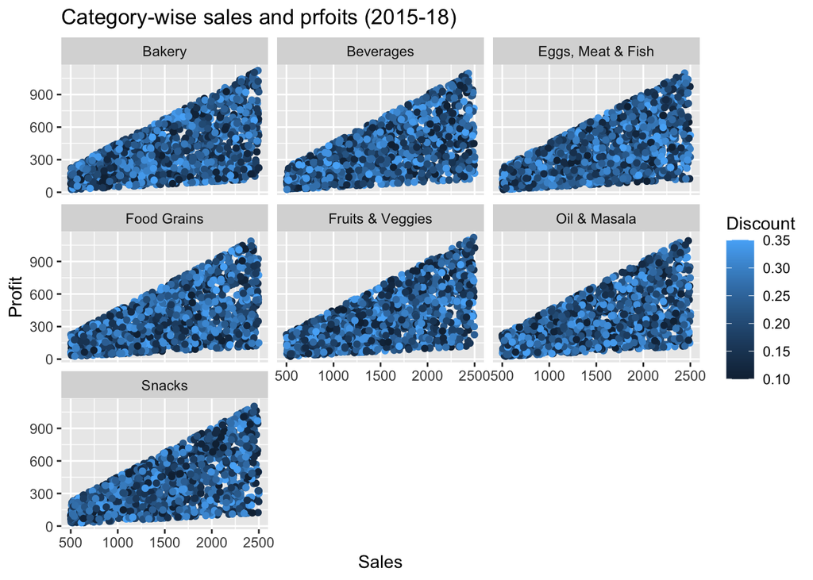

```r
ggplot(data=sales_data) + geom_point(mapping= aes(x=Sales, y=Profit, color=Discount))+
  facet_wrap(~Category)+labs(title="Category-wise sales and prfoits (2015-18)")
```

##### Let’s check average profits, sales and discount.

```r
profit_summary <- sales_data %>%
  group_by(year) %>%
  summarise(mean(Sales), mean(Profit), mean(Discount))
head(profit_summary)
```

```
## # A tibble: 4 × 4
##   year  `mean(Sales)` `mean(Profit)` `mean(Discount)`
##   <chr>         <dbl>          <dbl>            <dbl>
## 1 2015          1493.           378.            0.229
## 2 2016          1490.           379.            0.227
## 3 2017          1497.           368.            0.227
## 4 2018          1503.           376.            0.225
```

##### To verify this, we will analyse category-wise sales.

```r
category_sales_count <- sales_data %>%
  group_by(year) %>%
  count(Category)
```

```r
category_sales_count %>%
  group_by(Category) %>%
arrange(desc(n))
```

```
## # A tibble: 28 × 3
## # Groups:   Category [7]
##    year  Category              n
##    <chr> <chr>             <int>
##  1 2018  Snacks              509
##  2 2018  Eggs, Meat & Fish   498
##  3 2018  Fruits & Veggies    473
##  4 2018  Food Grains         470
##  5 2018  Bakery              463
##  6 2018  Beverages           462
##  7 2018  Oil & Masala        437
##  8 2017  Food Grains         395
##  9 2017  Snacks              393
## 10 2017  Eggs, Meat & Fish   372
## # ℹ 18 more rows
```

##### *Snacks was the most sold category in 2018.*

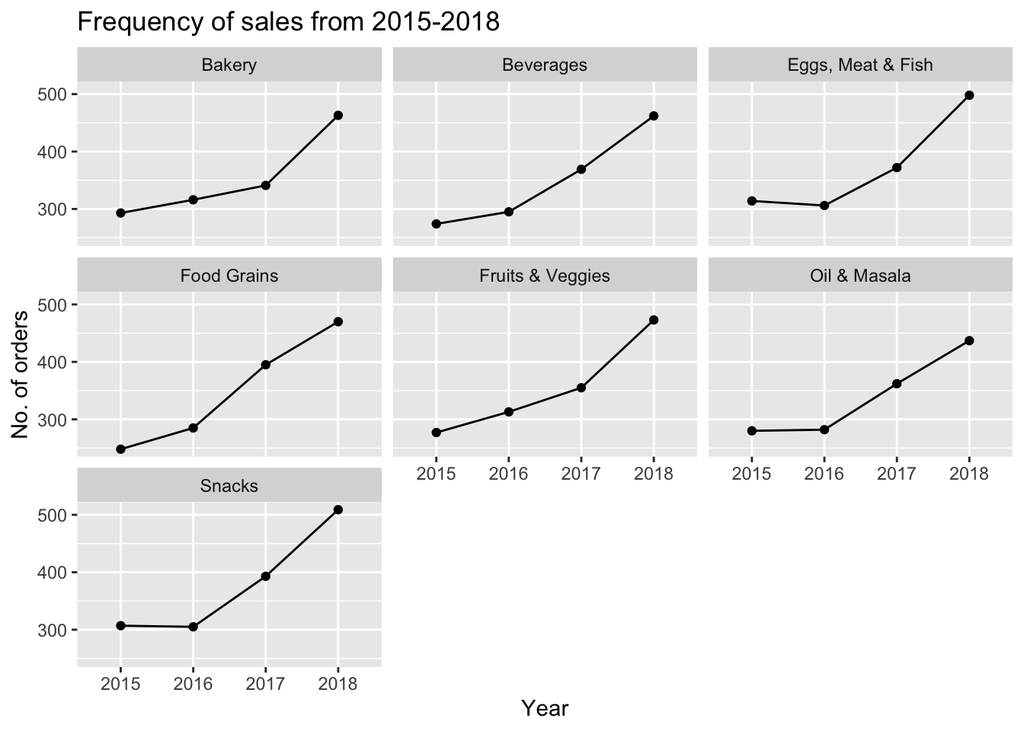

```r
ggplot(data=category_sales_count, aes(x=year, y=n, group=1)) + geom_line() +
  geom_point() + facet_wrap(~Category) + labs(title="Frequency of sales from 2015-2018", x="Year", y="No. of orders")
```

##### The above graphs show the trends in categoric sales for years 2015-18.

##### Overall there is an increase in orders in every category.

##### Now, we will check the most profitable category.

```r
profitable_category <- sales_data %>%
  group_by(Category, year) %>%
  summarise(average_profit = mean(Profit))
head(profitable_category)
```

```
## # A tibble: 6 × 3
## # Groups:   Category [2]
##   Category  year  average_profit
##   <chr>     <chr>          <dbl>
## 1 Bakery    2015            367.
## 2 Bakery    2016            394.
## 3 Bakery    2017            358.
## 4 Bakery    2018            377.
## 5 Beverages 2015            383.
## 6 Beverages 2016            374.
```

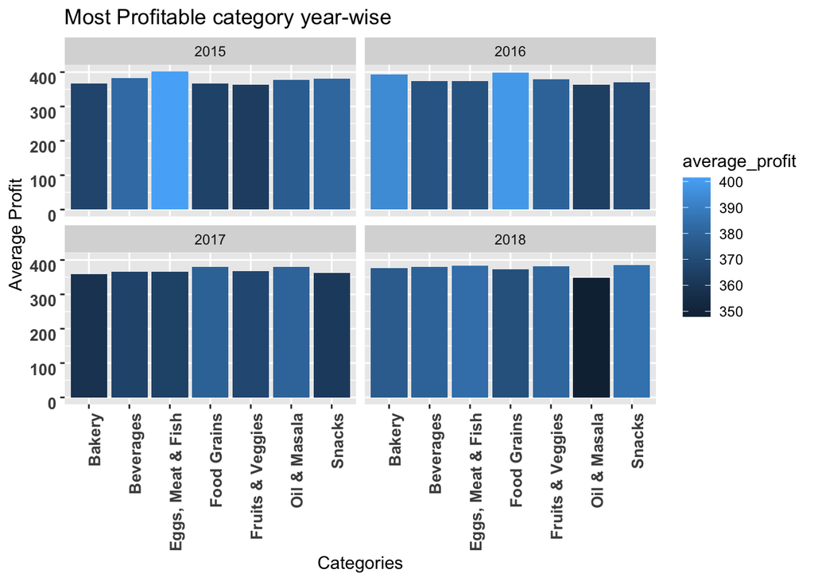

```r
ggplot(data=profitable_category, aes(x=Category, fill=average_profit))+
  geom_col(aes(y=average_profit)) + facet_wrap(~year)+
labs(title = "Most Profitable category year-wise",
     x = "Categories",
     y = "Average Profit") + theme(axis.text.x = element_text(size = 10, hjust = 1, face="bold", angle = 90), axis.text.y = element_text(size=10, vjust=1, face="bold"))
```

##### *The figures show that eggs, meat were most profitable category in 2015, snacks joined the group in 2018.*

##### Eggs meat and fish might be profitable due to surge pricing in the industry. We don’t have any information on grocery prices and hence will limit our exploration to the available data.

##### Now, we will analyse sales.

```r
average_categoric_sales <- sales_data %>%
  group_by(Category, year) %>%
  summarise(average_sales=mean(Sales))
```

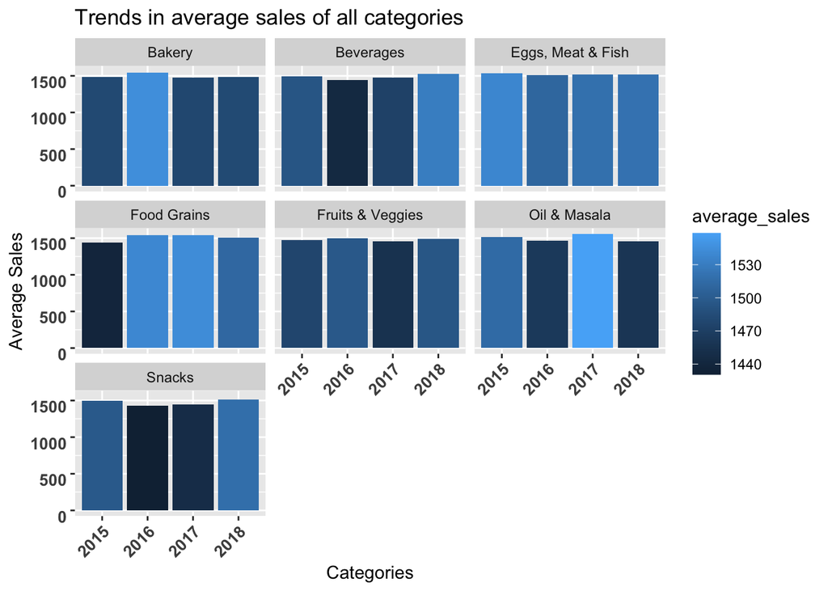

```r
ggplot(data=average_categoric_sales, aes(x=year, fill=average_sales))+
  geom_col(aes(y=average_sales))+ facet_wrap(~Category)+
labs(title = "Trends in average sales of all categories", x = "Categories", y = "Average Sales") +
  theme(axis.text.x = element_text(size = 10, hjust = 1, face="bold", angle = 45), axis.text.y = element_text(size=10, vjust=1, face="bold"))
```

##### *The visualisation shows that although the sales have increased in the final year that is 2018, the percentage increase is relatively low.*

##### Now we will analyse cities with highest and lowest sales.

```r
city_wise_sales <- sales_data %>%

  select(Profit, Sales, Category, City, year,Discount) %>%
  group_by(City)

total_sales_by_city <- city_wise_sales %>%
  group_by(City, year) %>%
  summarize(total_sales_city = sum(Sales))
head(total_sales_by_city)
```

```
## # A tibble: 6 × 3
## # Groups:   City [2]
##   City    year  total_sales_city
##   <chr>   <chr>            <dbl>
## 1 Bodi    2015            141653
## 2 Bodi    2016            156201
## 3 Bodi    2017            138697
## 4 Bodi    2018            230626
## 5 Chennai 2015            136731
## 6 Chennai 2016            145579
```

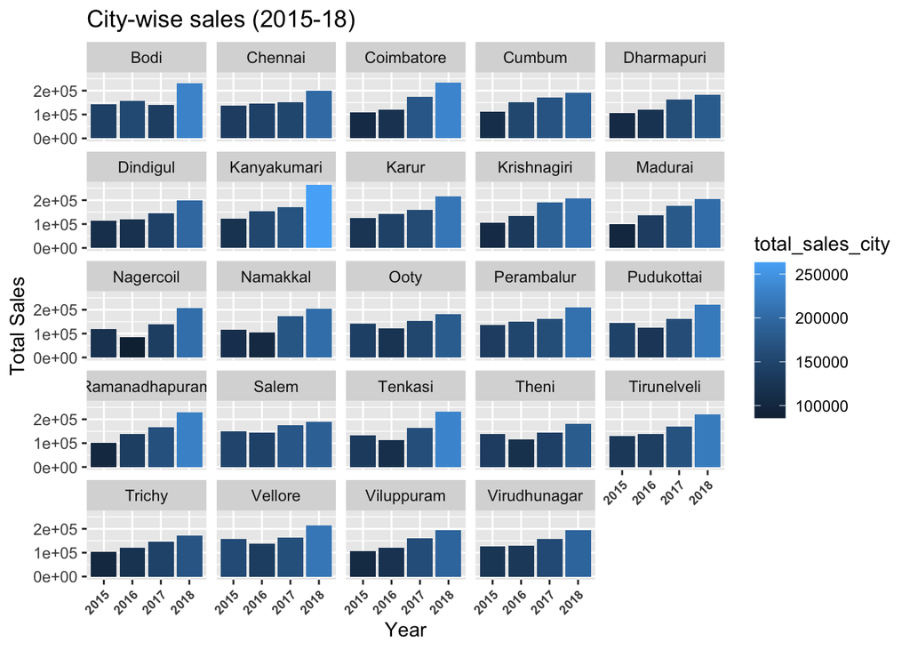

```r
ggplot(data=total_sales_by_city, aes(x=year)) +
  geom_col(aes(y=total_sales_city, fill=total_sales_city)) +
  facet_wrap(~City) + labs(title = "City-wise sales (2015-18)", x="Year", y="Total Sales")+
  theme(axis.text.x = element_text(size = 7, hjust = 1, face="bold", angle = 45))
```

##### These graphs show that maximum sales occured in Kanyakumari while minimum sales occured in Trichy.

```r
city_sales_2018 <- total_sales_by_city %>%
  filter(year==2018)
View(city_sales_2018)
```

```r
max(city_sales_2018$total_sales_city)
```

```
## [1] 263243
```

```r
min(city_sales_2018$total_sales_city)
```

```
## [1] 171989
```

##### This confirms that maximum sales occured in Kanyakumari while minimum in Trichy.

##### We will analyse trends for both Kanyakumari and Trichy for the year 2018.

##### Creating a new dataframe for Kanyakumari

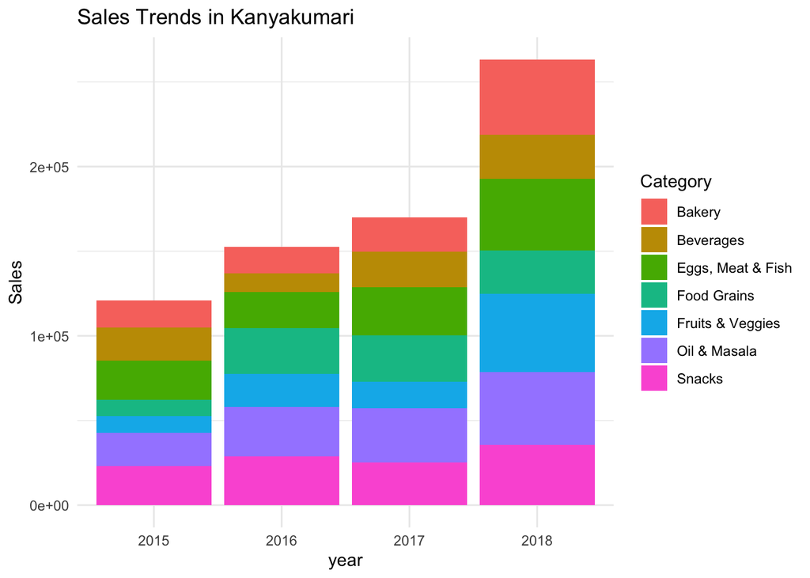

```r
kanyakumari_data <- city_wise_sales %>%
  filter(City == "Kanyakumari")

#Plotting Kanyakumari sale trends

ggplot(kanyakumari_data, aes(x=year, y=Sales, fill=Category)) + geom_col()+
  labs(title = "Sales Trends in Kanyakumari", x = "year", y = "Sales") +
  theme_minimal()
```

##### Let’s summarise the overall metrics

```r
kanyakumari_data %>%
  group_by(year) %>%
  summarise(avg_discount = mean(Discount), avg_profit = mean(Profit), avg_sales=mean(Sales))
```

```
## # A tibble: 4 × 4
##   year  avg_discount avg_profit avg_sales
##   <chr>        <dbl>      <dbl>     <dbl>
## 1 2015         0.223       349.     1424.
## 2 2016         0.231       395.     1556.
## 3 2017         0.222       385.     1545.
## 4 2018         0.220       371.     1586.
```

#### *There is a spike in average sales for 2018 but average profits and discount have declined.*

##### This may mean that high value product categories were sold more compared to low value categories or the quantity sold were significantly higher. The data is inadequate to comment on that.

##### Verifying the sales trends in Trichy

```r
trichy_data <- city_wise_sales %>%
  filter(City == "Trichy")
```

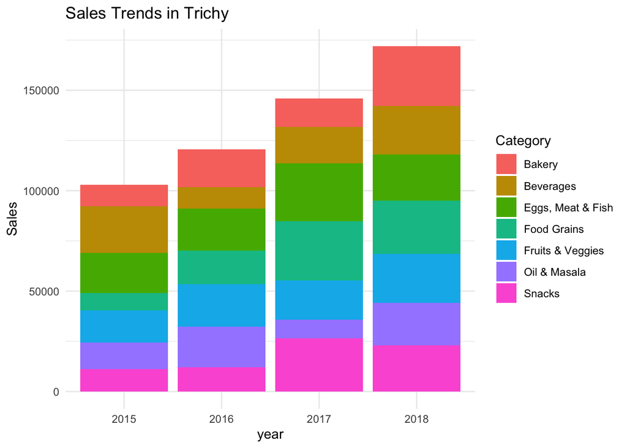

```r
ggplot(trichy_data, aes(x=year, y=Sales, fill=Category)) + geom_col()+
  labs(title = "Sales Trends in Trichy", x = "year", y = "Sales") +
  theme_minimal()
```

##### *There is a significant increase in sales from 2017 to 2018.*

##### To check which category was most sold and the percentage change in sales in Trichy-

```r
total_sales_by_category_trichy <- trichy_data %>%
  group_by(Category, year) %>%
  summarize(total_sales = sum(Sales))
head(total_sales_by_category_trichy)
```

```
## # A tibble: 6 × 3
## # Groups:   Category [2]
##   Category  year  total_sales
##   <chr>     <chr>       <dbl>
## 1 Bakery    2015        10853
## 2 Bakery    2016        18639
## 3 Bakery    2017        14150
## 4 Bakery    2018        29737
## 5 Beverages 2015        23139
## 6 Beverages 2016        10854
```

##### Visualising the categoric sales

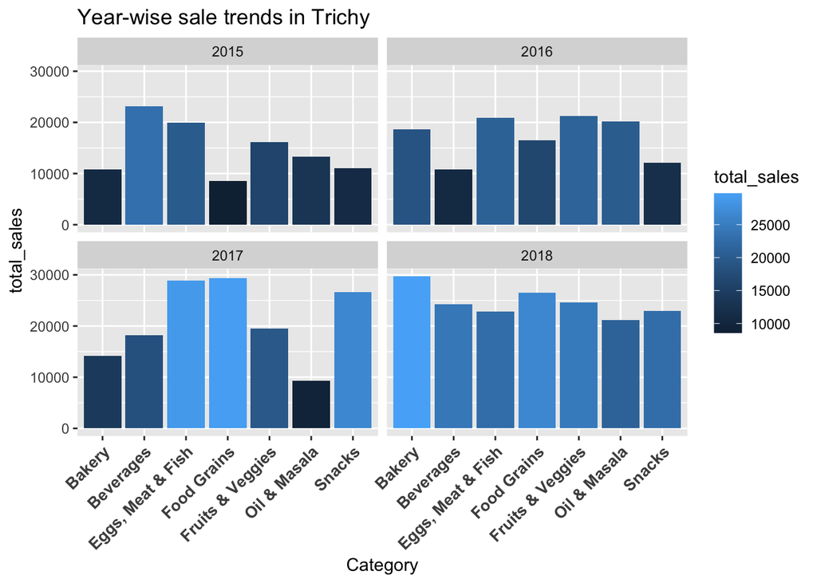

```r
ggplot(data=total_sales_by_category_trichy, aes(x=Category, y=total_sales, fill=total_sales))+facet_wrap(~year)+
  geom_col()+labs(title="Year-wise sale trends in Trichy")+theme(axis.text.x = element_text(size = 10, hjust = 1, face="bold", angle = 45))
```

##### *In 2018, sales for Bakery products were highest followed by food grains and fruits and veggies.*

##### Now we will calculate percentage change in sales for all the categories

```r
percentage_change_sales_trichy <- total_sales_by_category_trichy %>%
  mutate(pct_change = ((total_sales/lag(total_sales) - 1)*100))
```

```r
head(percentage_change_sales_trichy)
```

```
## # A tibble: 6 × 4
## # Groups:   Category [2]
##   Category  year  total_sales pct_change
##   <chr>     <chr>       <dbl>      <dbl>
## 1 Bakery    2015        10853       NA
## 2 Bakery    2016        18639       71.7
## 3 Bakery    2017        14150      -24.1
## 4 Bakery    2018        29737      110.
## 5 Beverages 2015        23139       NA
## 6 Beverages 2016        10854      -53.1
```

##### The dataframe has some null values. That is simply because we don’t have data for year previous to 2015.

##### Let’s filter the category with maximum percentage change in sales.

```r
max_change_category <- percentage_change_sales_trichy %>%
  filter(pct_change == max(pct_change, na.rm = TRUE))
print("Category with significant change in sales in Trichy:")
```

```
## [1] "Category with significant change in sales in Trichy:"
```

```r
print(max_change_category)
```

```
## # A tibble: 7 × 4
## # Groups:   Category [7]
##   Category          year  total_sales pct_change
##   <chr>             <chr>       <dbl>      <dbl>
## 1 Bakery            2018        29737      110.
## 2 Beverages         2017        18184       67.5
## 3 Eggs, Meat & Fish 2017        28843       37.8
## 4 Food Grains       2016        16530       92.7
## 5 Fruits & Veggies  2016        21285       32.3
## 6 Oil & Masala      2018        21166      128.
## 7 Snacks            2017        26576      120.
```

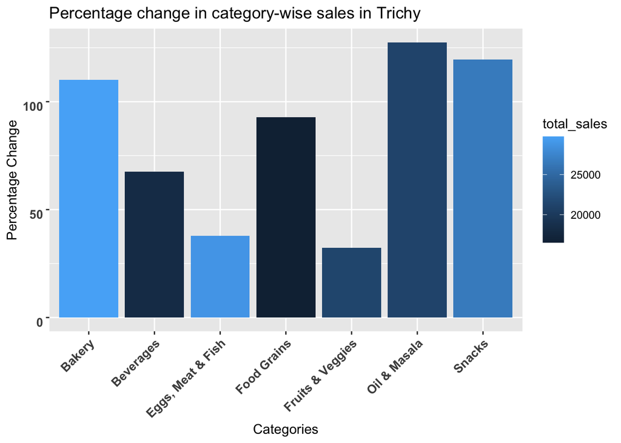

```r
ggplot(data=max_change_category, aes(x=Category))+ geom_col(aes(y=pct_change, fill=total_sales))+
  labs(title = "Percentage change in category-wise sales in Trichy",x = "Categories",y = "Percentage Change")+
         theme(axis.text.x = element_text(size = 10, hjust = 1,face="bold", angle = 45),
                                         axis.text.y = element_text(size=10, vjust=1, face="bold"))
```

##### But which category was sold the most in Trichy.

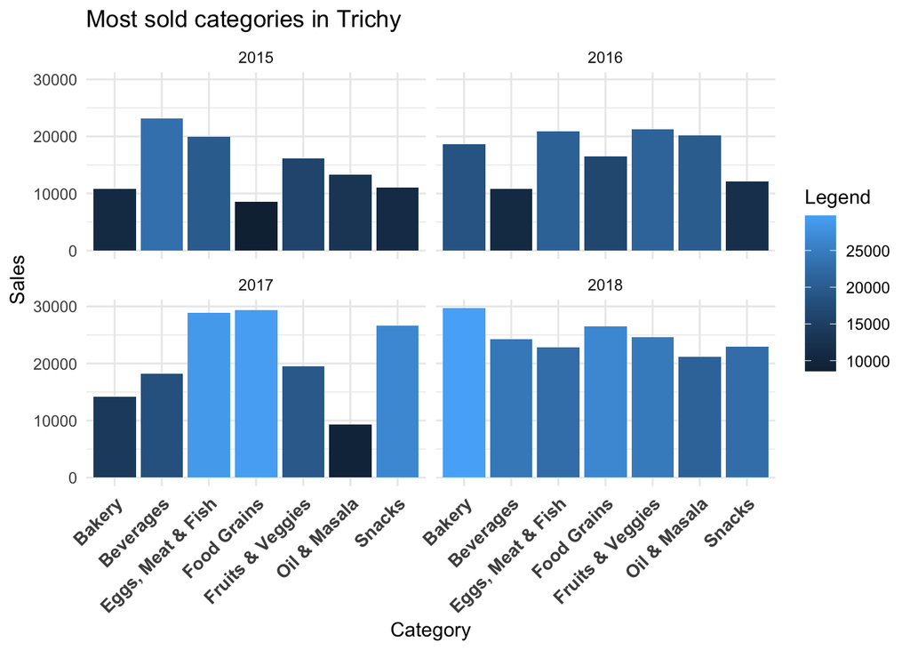

```r
ggplot(data= total_sales_by_category_trichy, aes(x=Category, y=total_sales, fill=total_sales))+
  geom_col()+ labs(title = "Most sold categories in Trichy",
                   x = "Category",
                   y = "Sales",
                   fill = "Legend") + theme_minimal() + facet_wrap(~year) +
  theme(axis.text.x = element_text(size = 10, hjust = 1, face="bold", angle = 45))
```

##### *Bakery products and food grains were most sold in 2018 in Trichy.*

##### Let’s check whether this is because of large discounts.

```r
average_discount <- sales_data %>%
  group_by(Category, year) %>%
  summarise(mean_discount=mean(Discount))
View(average_discount)
```

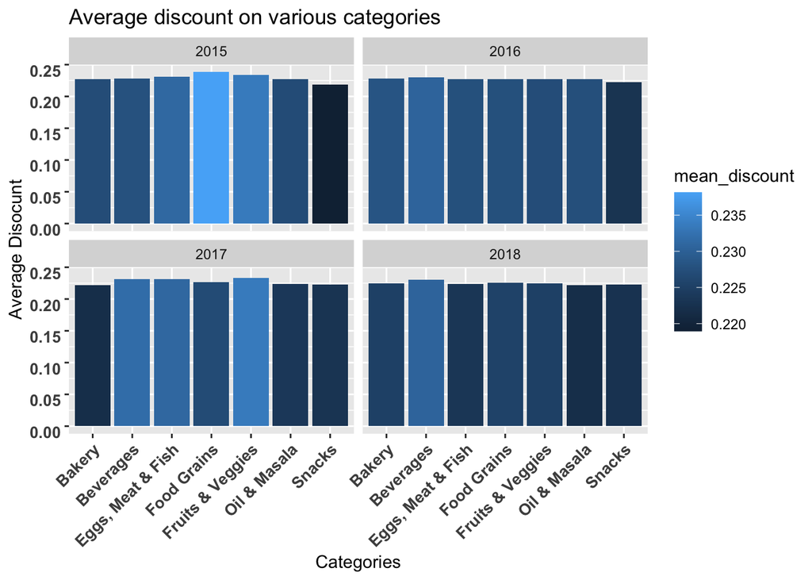

```r
ggplot(data=average_discount, aes(x=Category, fill=mean_discount))+
  geom_col(aes(y=mean_discount)) +
  labs(title = "Average discount on various categories", x = "Categories",y = "Average Disocunt") +
  theme(axis.text.x = element_text(size = 10, hjust = 1, face="bold", angle = 45), axis.text.y = element_text(size=10, vjust=1, face="bold")) +
  facet_wrap(~year)
```

#### Here are few observations after analysing the entire dataset across various categories

##### 5) We need addtional data points like price per subcategory to analyse most profitable categories based on selling price.